# Lab Five: Wide and Deep Networks

### 7 layers

```
Train on 101056 samples, validate on 40423 samples
0.9338155764616918
Train on 101056 samples, validate on 40423 samples
0.9352355135877236
Train on 101056 samples, validate on 40423 samples
0.9341986662068271
Train on 101056 samples, validate on 40423 samples
0.9344583718270121
Train on 101056 samples, validate on 40423 samples
0.9327304583460452
Train on 101056 samples, validate on 40423 samples
0.9344144607954874
Train on 101056 samples, validate on 40423 samples
0.9352796680753445
Train on 101056 samples, validate on 40423 samples
0.9339677174245917
Train on 101056 samples, validate on 40423 samples
0.9334189206196621
Train on 101056 samples, validate on 40423 samples
0.9346685529797988
```

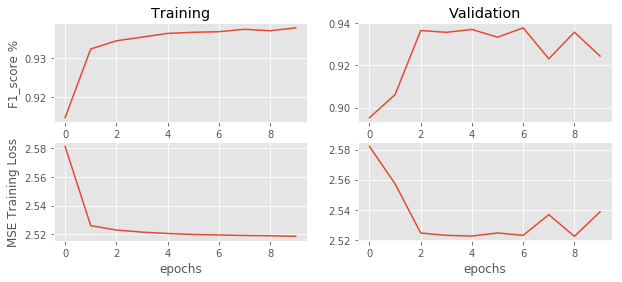

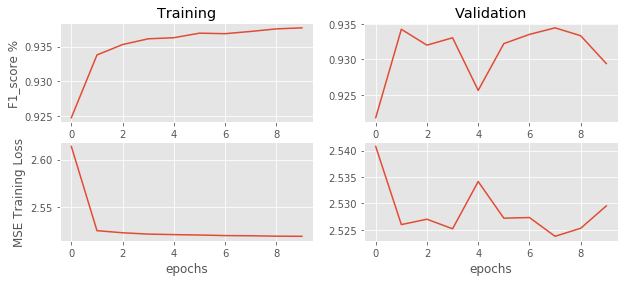

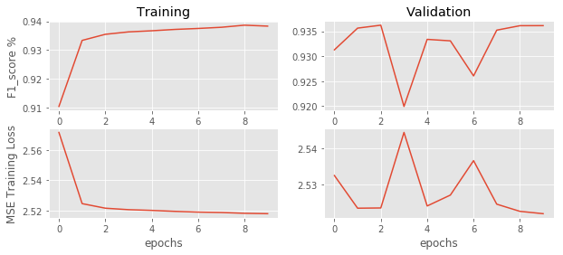

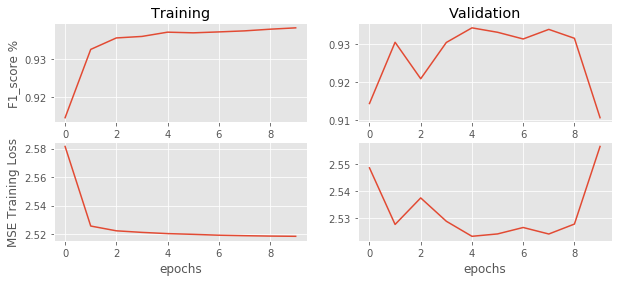

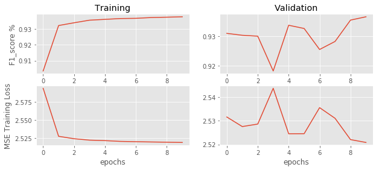

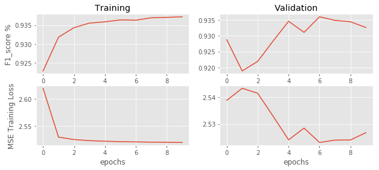

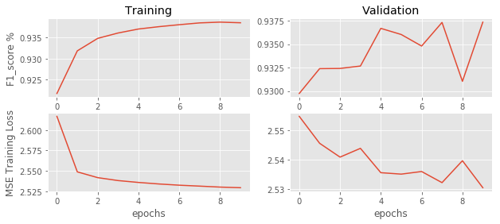

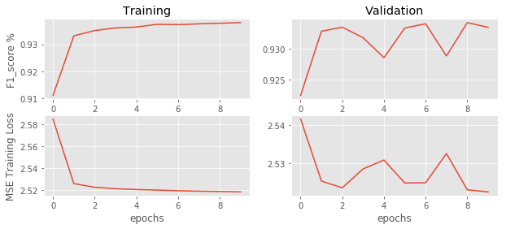

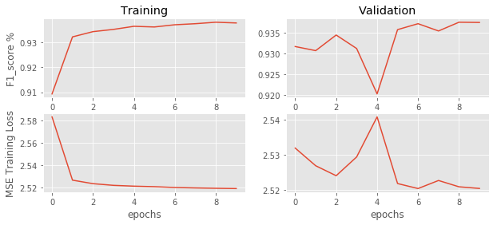

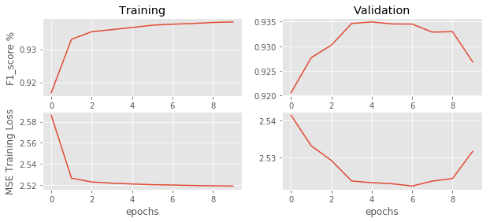

```python
acc7 = 0
for train_index, test_index in cv2.split(X, y):
    X_train, X_test= df_clean.iloc[train_index],df_clean.iloc[test_index]
    y_train, y_test= df_clean['pricerange'].iloc[train_index],df_clean['pricerange'].iloc[test_index]

    ohe = OneHotEncoder()
    X_train_ohe = ohe.fit_transform(X_train[categorical_headers_ints].values)
    X_test_ohe = ohe.transform(X_test[categorical_headers_ints].values)

    X_train_num =  X_train[numeric_headers].values
    X_test_num = X_test[numeric_headers].values

    from keras.layers import concatenate
    cross_columns = [['brand','model'],
                 ['brand','vehicleType'],
                 ['gearbox','model'],
                 ['fuelType','notRepairedDamage']]

# we need to create separate lists for each branch
    embed_branches = []
    X_ints_train = []
    X_ints_test = []
    all_inputs = []
    all_wide_branch_outputs = []

    for cols in cross_columns:
        # encode crossed columns as ints for the embedding
        enc = LabelEncoder()

        # create crossed labels
        X_crossed_train = X_train[cols].apply(lambda x: '_'.join(x), axis=1)
        X_crossed_test = X_test[cols].apply(lambda x: '_'.join(x), axis=1)

        enc.fit(np.hstack((X_crossed_train.values,  X_crossed_test.values)))
        X_crossed_train = enc.transform(X_crossed_train)
        X_crossed_test = enc.transform(X_crossed_test)
        X_ints_train.append( X_crossed_train )
        X_ints_test.append( X_crossed_test )

        # get the number of categories
        N = max(X_ints_train[-1]+1) # same as the max(df_train[col])

        # create embedding branch from the number of categories
        inputs = Input(shape=(1,),dtype='int32', name = '_'.join(cols))
        all_inputs.append(inputs)
        x = Embedding(input_dim=N,
                      output_dim=int(np.sqrt(N)),
                      input_length=1, name = '_'.join(cols)+'_embed')(inputs)
        x = Flatten()(x)
        all_wide_branch_outputs.append(x)

# merge the branches together
    wide_branch = concatenate(all_wide_branch_outputs, name='wide_concat')
    wide_branch = Dense(units=1,activation='sigmoid',name='wide_combined')(wide_branch)

    # reset this input branch
    all_deep_branch_outputs = []
    # add in the embeddings
    for col in categorical_headers_ints:
        # encode as ints for the embedding
        X_ints_train.append( X_train[col].values )
        X_ints_test.append( X_test[col].values )

        # get the number of categories
        N = max(X_ints_train[-1]+1) # same as the max(df_train[col])

        # create embedding branch from the number of categories
        inputs = Input(shape=(1,),dtype='int32', name=col)
        all_inputs.append(inputs)
        x = Embedding(input_dim=N,
                      output_dim=int(np.sqrt(N)),
                      input_length=1, name=col+'_embed')(inputs)
        x = Flatten()(x)
        all_deep_branch_outputs.append(x)

    # also get a dense branch of the numeric features
    all_inputs.append(Input(shape=(X_train_num.shape[1],),
                            sparse=False,
                            name='numeric_data'))

    x = Dense(units=20, activation='relu',name='numeric_1')(all_inputs[-1])
    all_deep_branch_outputs.append( x )

    # merge the deep branches together
    deep_branch = concatenate(all_deep_branch_outputs,name='concat_embeds')
    deep_branch = Dense(units=70,activation='relu', name='deep1')(deep_branch)
    deep_branch = Dense(units=50,activation='relu', name='deep2')(deep_branch)
    deep_branch = Dense(units=35,activation='relu', name='deep3')(deep_branch)
    deep_branch = Dense(units=25,activation='relu', name='deep4')(deep_branch)
    deep_branch = Dense(units=20,activation='relu', name='deep5')(deep_branch)
    deep_branch = Dense(units=15,activation='relu', name='deep6')(deep_branch)
    deep_branch = Dense(units=10,activation='relu', name='deep7')(deep_branch)





    final_branch = concatenate([wide_branch, deep_branch],name='concat_deep_wide')
    final_branch = Dense(units=1,activation='sigmoid',name='combined')(final_branch)

    model7 = Model(inputs=all_inputs, outputs=final_branch)

    model7.compile(optimizer='adagrad',
              loss='mean_squared_error',
              metrics=[f1])

# lets also add the history variable to see how we are doing
# and lets add a validation set to keep track of our progress
    history = model7.fit(X_ints_train+ [X_train_num],
                    y_train,
                    epochs=10,
                    batch_size=1000,
                    verbose=1,
                    validation_data = (X_ints_test + [X_test_num], y_test))

    a = np.sum(history.history['f1'])/10
    acc7 += a
    print(a)


    plt.figure(figsize=(10,4))
    plt.subplot(2,2,1)
    plt.plot(history.history['f1'])

    plt.ylabel('F1_score %')
    plt.title('Training')
    plt.subplot(2,2,2)
    plt.plot(history.history['val_f1'])
    plt.title('Validation')

    plt.subplot(2,2,3)
    plt.plot(history.history['loss'])
    plt.ylabel('MSE Training Loss')
    plt.xlabel('epochs')

    plt.subplot(2,2,4)
    plt.plot(history.history['val_loss'])
    plt.xlabel('epochs')
```

```python
acc_7_layer = acc7/10
print(acc_7_layer)
```

```
0.9342187906324184
```

The average accuracy of f1_score is 0.9342187906324184.

```python
from IPython.display import SVG
from keras.utils.vis_utils import model_to_dot

SVG(model_to_dot(model7).create(prog='dot', format='svg'))
```

[figure not shown]

```python
com = pd.DataFrame
index = ['3_layers','4_layers','7_layers']
columns = ['Layers','Average Accuracy']
com= pd.DataFrame(columns = columns)
accc = (acc_3_layer, acc_4_layer, acc_7_layer)
com['Layers'] = index
com['Average Accuracy'] = np.array(accc)
com
```

|  | Layers | Average Accuracy |
| --- | --- | --- |
| 0 | 3_layers | 0.932653 |
| 1 | 4_layers | 0.933513 |
| 2 | 7_layers | 0.934219 |

From the table, we get that when layers = 7, for our dataset,the result is the best, and 4_layers model is the second best one.

## 2.3 Compare to a standard multi-layer perceptron (MLP)

```python
from sklearn import __version__ as sklearn_version
from sklearn.neural_network import MLPClassifier
from sklearn.metrics import make_scorer,f1_score
from sklearn.model_selection import StratifiedKFold, StratifiedShuffleSplit, cross_val_score

print(sklearn_version)
```

```
0.20.2
```

```python
#cv2 = StratifiedShuffleSplit(n_splits=10)
for train_index, test_index in cv2.split(X, y):
    df_train, df_test= df_clean.iloc[train_index],df_clean.iloc[test_index]
    #print('train',train_index,'test',test_index)
```

```python
X_train =  ss.fit_transform(df_train[feature_columns].values).astype(np.float32)
X_test =  ss.transform(df_test[feature_columns].values).astype(np.float32)

y_train = df_train['pricerange'].values.astype(np.int)
y_test = df_test['pricerange'].values.astype(np.int)
```

```python
clf = MLPClassifier(hidden_layer_sizes=(50, ),
                    activation='logistic',
                    solver='sgd',
                    alpha=1e-4, # L2 penalty
                    batch_size=1000, # min of 200, num_samples
                    learning_rate='constant',
                    learning_rate_init=0.1, # only SGD
                    power_t=0.5,    # only SGD
                    max_iter=75,
                    shuffle=True,
                    random_state=1,
                    tol=1e-9, # for stopping
                    verbose=False,
                    warm_start=False,
                    momentum=0.9, # only SGD
                    nesterovs_momentum=True, # only SGD
                    early_stopping=False,
                    validation_fraction=0.1, # only if early_stop is true
                    beta_1=0.9, # adam decay rate of moment
                    beta_2=0.999, # adam decay rate of moment
                    epsilon=1e-08) # adam numerical stabilizer

#clf.fit(X_train,y_train)
#yhat = clf.predict(X_test)
#print('Validation Acc:',f1_score(yhat,y_test,average='micro'))
```

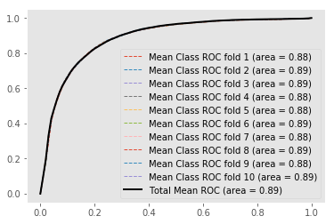

```python
from sklearn.metrics import roc_curve, auc
from scipy import interp
from sklearn.model_selection import StratifiedShuffleSplit
ssf = cv2.split(X_train,y_train)

mean_tpr = 0.0
mean_fpr = np.linspace(0, 1, 100)
all_tpr = []

for i, (train, test) in enumerate(ssf):
    probas = pipe_lr.fit(X_train[train],
                         y_train[train]).predict_proba(X_train[test])

    perclass_mean_tpr = 0.0
    roc_auc = 0
    classes = np.unique(y_train[train])
    # get the mean fpr and tpr, per class
    for j in classes:
        fpr, tpr, thresholds = roc_curve(y_train[test],
                                         probas[:, j],
                                         pos_label=j)
        perclass_mean_tpr += interp(mean_fpr, fpr, tpr)
        perclass_mean_tpr[0] = 0.0
        roc_auc += auc(fpr, tpr)

    perclass_mean_tpr /= len(classes)
    roc_auc /= len(classes)
    mean_tpr += perclass_mean_tpr
    plt.plot(mean_fpr,perclass_mean_tpr,'--',lw=1,label='Mean Class ROC fold %d (area = %0.2f)'
                   % (i+1, roc_auc))

mean_tpr /= 10
mean_auc = auc(mean_fpr, mean_tpr)
plt.plot(mean_fpr,perclass_mean_tpr,'k-',lw=2,label='Total Mean ROC (area = %0.2f)'
                   % (mean_auc))
plt.legend(loc='best')
plt.grid()
```

# 3 Exceptional Work

There are 11 variables in our dataset, which means that a lot of features need to be explored and understood.T-sne is very suitable for high-dimension datasets so we choose to do the t-sne here and calculate the probabilities of similar observations in the low-dimentional dataset. What's more, from the embedding weights in deep network, we could get the information that most the relationships between them are not linear and t-SNE is good at capturing non-linear dependencies.

```python
from sklearn.manifold import TSNE
#from umap import UMAP
from keras.layers import Input, Embedding, Dot, Reshape, Dense
from keras.models import Model
```

Since from the previous part, we can get that when wide and deep model has 7 layers, it has the best performance, so we choose the 7 layers model to do our work. Since we chosed these four cross product features:brand X model, brand X vehicleType, gearbox X model, fuelType X notRepairedDamage at the very beginning, so there are four embeds about them in our model. We decided to use T-sne to perform these four embeds dimensionality reduction in order to visualize results.

```python
embeding = model7.get_layer('brand_vehicleType_embed').get_weights()[0]
embeding.shape
```

```
(261, 16)
```

```python
X_embedded = TSNE(n_components=2, perplexity=40.0, early_exaggeration=12.0, learning_rate=200.0, n_iter=500,
                    n_iter_without_progress=300, min_grad_norm=1e-07, metric='euclidean', init='random',
                    verbose=0, random_state=None, method='barnes_hut',angle=0.5).fit_transform(embeding)
```

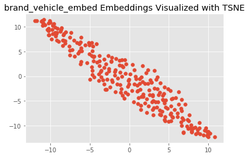

```python
x1_data = X_embedded[:, 0]
y1_data = X_embedded[:, 1]
plt.scatter(x1_data, y1_data)
plt.title("brand_vehicle_embed Embeddings Visualized with TSNE")
plt.show()
```

```python
embeding2 = model7.get_layer('brand_model_embed').get_weights()[0]
embeding2.shape
```

```
(290, 17)
```

```python
X_embedded2 = TSNE(n_components=2, perplexity=40.0, early_exaggeration=12.0, learning_rate=200.0, n_iter=500,
                    n_iter_without_progress=300, min_grad_norm=1e-07, metric='euclidean', init='random',
                    verbose=0, random_state=None, method='barnes_hut',angle=0.5).fit_transform(embeding2)
```

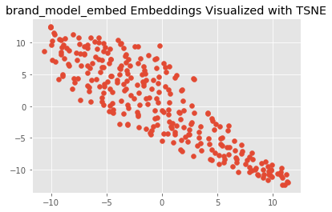

```python
x2_data = X_embedded2[:, 0]
y2_data = X_embedded2[:, 1]
plt.scatter(x2_data, y2_data)
plt.title("brand_model_embed Embeddings Visualized with TSNE")
plt.show()
```

```python
embeding3 = model7.get_layer('gearbox_model_embed').get_weights()[0]
embeding3.shape
```

```
(468, 21)
```

```python
X_embedded3 = TSNE(n_components=2, perplexity=40.0, early_exaggeration=12.0, learning_rate=200.0, n_iter=500,
                    n_iter_without_progress=300, min_grad_norm=1e-07, metric='euclidean', init='random',
                    verbose=0, random_state=None, method='barnes_hut',angle=0.5).fit_transform(embeding3)
```

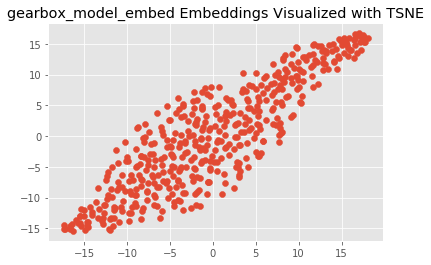

```python
x3_data = X_embedded3[:, 0]
y3_data = X_embedded3[:, 1]
plt.scatter(x3_data, y3_data)
plt.title("gearbox_model_embed Embeddings Visualized with TSNE")
plt.show()
```

```python
embeding4 = model7.get_layer('fuelType_notRepairedDamage_embed').get_weights()[0]
embeding4.shape
```

```
(20, 4)
```

```python
X_embedded4 = TSNE(n_components=2, perplexity=40.0, early_exaggeration=12.0, learning_rate=200.0, n_iter=500,
                    n_iter_without_progress=300, min_grad_norm=1e-07, metric='euclidean', init='random',
                    verbose=0, random_state=None, method='barnes_hut',angle=0.5).fit_transform(embeding4)
```

[figure not shown]

```python
x4_data = X_embedded4[:, 0]
y4_data = X_embedded4[:, 1]
plt.scatter(x2_data, y2_data)
plt.title("fuelType_notRepairedDamage_embed Embeddings Visualized with TSNE")
plt.show()
```

We would like to get a plot which based on the different kind of embed vectors such as 'brand_model_embed', it can show us the separated cluster based on different colors, we think this part can be improved. however due to our ability and limited time, we only generate the plots showed above.

## References

Dataset Source: https://www.kaggle.com/orgesleka/used-cars-database  
https://www.kbb.com/  
https://hedgescompany.com/automotive-market-research-statistics/auto-mailing-lists-and-marketing/  
https://www.statista.com/statistics/183713/value-of-us-passenger-cas-sales-and-leases-since-1990/  
https://stackoverflow.com/questions/45969390/difference-between-stratifiedkfold-and-stratifiedshufflesplit-in-sklearn  
https://stackoverflow.com/questions/43547402/how-to-calculate-f1-macro-in-keras  
https://github.com/keras-team/keras/wiki/Keras-2.0-release-notes  
https://github.com/WillKoehrsen/wikipedia-data-science/blob/master/notebooks/Book%20Recommendation%20System.ipynb  
https://github.com/eclarson/MachineLearningNotebooks/blob/master/10.%20Keras%20Wide%20and%20Deep.ipynb